# Machine Learning

## O que devemos saber

- Existe a bastante tempo mas só recemente vem se popularizando
- Companhias querem usar ML, mas não possuem certeza sobre o que é isso ou aonde aplicar
- Possui um grande potencial mas não da resultados instantaneos, é preciso responder as perguntas certas e planejar cuidadosamente o projeto
- Tenha certeza que você possui: dados certos, pessoas e processos. Se tudo estiver certo, tenha certeza que um projeto de ML pode salvar boas quantias de dinheiro e aumetar a produtividade após algum meses de desenvolvimento!

## Aplicações

### Analises e Manutenção Preditivas

- Falhas e Configuração de Equipamentos
- Controle de Qualidade
- Quais ações são mais efetivas
- Escolha de investimentos e parceiros
- Previsão de demanda
- Treinamentos de robôs

## Passos para Aplicação de ML

### Dados

- Coletar fontes diferentes. Históricos, ERP, etc.
- Coleta automizada
- Qualidade é mais importante que quantidade

### Classificar Dados

- Pessoas domínio do processo para classificar os dados como bons ou ruins

### Escolher uma questão

- Começar com o que você realmente quer saber
- Função de custo

### Usar conhecimento do processo (Domain Knowledge)

- Quais dados podem responder sua questão?
- É possível adquirir dados nulos?
- Qual a qualidade dos dados?
- Eliminar variáveis dependentes. Mais atributos = Modelo mais complexo.

### ETL (Extract, Transform, Load)

- Posso automatizar cada passo?
- Posso obter novos dados automaticamente?
- O quão limpos os dados devem estar?
- Como os valores nulos serão manipulados? Remoção completa, substituído pela média ou pelo valor recorrente?

### Visualizar seus dados

Procurar por:

- Problemas nos dados
- Tendências
- Algoritmo

### Qual algoritmo usar?

- Classificação ou Regressão?
- Dados Classificados ou não classificados?
- Regras de associação
- Tolerante a dados nulos?
- Aprendizado Incremental/Tardio (Lazy Learners)? Gerar um novo modelo(retraining)?
- Black box vs Maior legibilidade?
- Tolerante a outliers?

### Qual plataforma utilizar?

- Computação na nuvem ou local?
- Quão flexível é?
- Quão fácil é obter dados nessa plataforma?
- Quão fácil é obter resultados utilizáveis? Poder ser automatizado?

### Testar o modelo

- Técnicas de testes
- Quão preciso é?
- Possuir históricos dos passos e reavaliar quando necessário

# Como Funciona

## Treinamento e Criação do Modelo!

[figure not shown]

## Predição pelo Computador

[figure not shown]

# Machine Learning em Python

## Exemplo utilizando a biblioteca [scikit-learn](http://scikit-learn.org/stable/) e algoritmo [KNN](http://scikit-learn.org/stable/modules/neighbors.html)

### Dataset utilizado: [Boston house prices](http://scikit-learn.org/stable/datasets/index.html#boston-house-prices-dataset)

Objetivo do exemplo é predizer o valor de um imóvel em Boston utilizando dados já existentes referente a outros imóveis.

```python
from sklearn.datasets import load_boston

import matplotlib.pyplot as plt
from sklearn.neighbors import KNeighborsRegressor

boston = load_boston()
#numero de vizinhos próximos
K = 9
#algoritmo para ser utilizado
knn = KNeighborsRegressor(n_neighbors=K)
```

### Separa os dados para serem utilizado no treinamento do algoritimo

- x são os dados de entrada
- y valor do imóvel

```python
#numero de registros utilizado para gerar o modelo
n_data = 100

x, y = boston.data[:n_data], boston.target[:n_data]
```

### Executa o Treino com os dados

```python
knn.fit(x, y)
```

```
KNeighborsRegressor(algorithm='auto', leaf_size=30, metric='minkowski',
          metric_params=None, n_jobs=None, n_neighbors=9, p=2,
          weights='uniform')
```

### Executa a Predição

```python
valor_predicao = knn.predict([boston.data[0]])
```

```python
valor_real= boston.target[0]

print("Valor Real: ",valor_real)
print("Valor Estimado: ",valor_predicao[0])
```

```
Valor Real:  24.0
Valor Estimado:  21.08888888888889
```

### Comparação entre Valores Preditos x Valores Reais

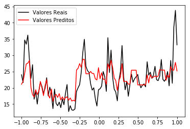

```python
import numpy as np

#Predizendo N_data valores
y_predicted = knn.predict(x)

#Visualização gráfica
plt.plot(np.linspace(-1, 1, n_data), y, label='Valores Reais', color='black')
plt.plot(np.linspace(-1, 1, n_data), y_predicted, label='Valores Preditos', color='red')
plt.legend()
plt.show()
```

### Ajustando parâmetros do algoritimo, como por exemplo o K, ou utilizando mais dados a precisão do modelo pode aumentar ou diminuir.